# NYPD Shooting Report

TranYuan Chen

2023-05-22

## About Data

List of every shooting incident that occurred in NYC going back to 2006 through the end of the previous calendar year.

This is a breakdown of every shooting incident that occurred in NYC going back to 2006 through the end of the previous calendar year. This data is manually extracted every quarter and reviewed by the Office of Management Analysis and Planning before being posted on the NYPD website. Each record represents a shooting incident in NYC and includes information about the event, the location and time of occurrence. In addition, information related to suspect and victim demographics are also included. This data can be used by the public to explore the nature of shooting/criminal activity. Please refer to the attached data footnotes for additional information about this dataset.

## Read Data

```r
library(tidyverse)
df = read_csv("https://data.cityofnewyork.us/api/views/833y-fsy8/rows.csv?accessType=DOWNLOAD")
head(df)
```

```
## # A tibble: 6 × 21
##   INCIDENT_KEY OCCUR_DATE OCCUR_TIME BORO     LOC_OF_OCCUR_DESC PRECINCT
##          <dbl> <chr>      <time>     <chr>    <chr>                <dbl>
## 1    228798151 05/27/2021 21:30      QUEENS   <NA>                   105
## 2    137471050 06/27/2014 17:40      BRONX    <NA>                    40
## 3    147998800 11/21/2015 03:56      QUEENS   <NA>                   108
## 4    146837977 10/09/2015 18:30      BRONX    <NA>                    44
## 5     58921844 02/19/2009 22:58      BRONX    <NA>                    47
## 6    219559682 10/21/2020 21:36      BROOKLYN <NA>                    81
## # ℹ 15 more variables: JURISDICTION_CODE <dbl>, LOC_CLASSFCTN_DESC <chr>,
## #   LOCATION_DESC <chr>, STATISTICAL_MURDER_FLAG <lgl>, PERP_AGE_GROUP <chr>,
## #   PERP_SEX <chr>, PERP_RACE <chr>, VIC_AGE_GROUP <chr>, VIC_SEX <chr>,
## #   VIC_RACE <chr>, X_COORD_CD <dbl>, Y_COORD_CD <dbl>, Latitude <dbl>,
## #   Longitude <dbl>, Lon_Lat <chr>
```

After reading the data, the columns that are interest to me are Boro, Vic_age_group, vic_sex and vic_race

## Including Plots

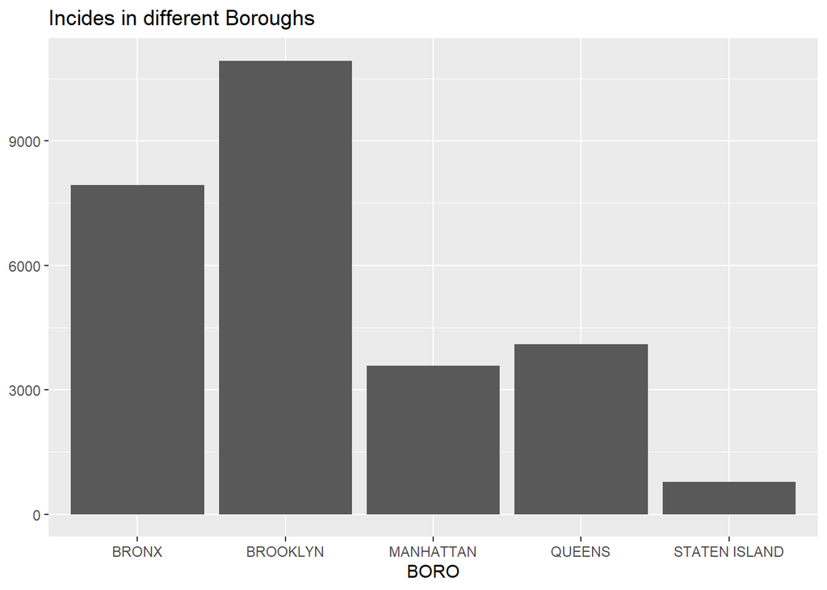

Brooklyn has the highest incidents.

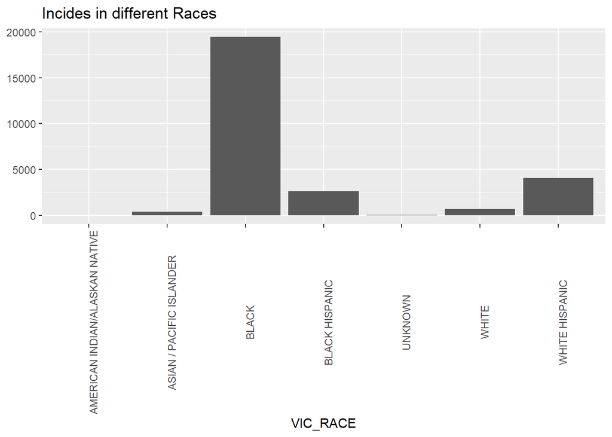

Black victim has the highest incidents.

## Including Model

```r
mod <- lm(STATISTICAL_MURDER_FLAG~ BORO + VIC_AGE_GROUP + VIC_SEX + VIC_RACE, data = df)
summary(mod)
```

```
##
## Call:
## lm(formula = STATISTICAL_MURDER_FLAG ~ BORO + VIC_AGE_GROUP +
##     VIC_SEX + VIC_RACE, data = df)
##
## Residuals:
##     Min      1Q  Median      3Q     Max
## -0.3670 -0.2162 -0.1688 -0.1298  0.9661
##
## Coefficients:
##                                   Estimate Std. Error t value Pr(>|t|)
## (Intercept)                      -0.035275   0.124538  -0.283  0.77699
## BOROBROOKLYN                     -0.003267   0.005992  -0.545  0.58559
## BOROMANHATTAN                    -0.020566   0.007927  -2.594  0.00948 **
## BOROQUEENS                       -0.003743   0.007671  -0.488  0.62562
## BOROSTATEN ISLAND                 0.004903   0.014881   0.329  0.74181
## VIC_AGE_GROUP1022                -0.112510   0.392732  -0.286  0.77451
## VIC_AGE_GROUP18-24                0.035671   0.008364   4.265 2.01e-05 ***
## VIC_AGE_GROUP25-44                0.086367   0.008207  10.524  < 2e-16 ***
## VIC_AGE_GROUP45-64                0.112941   0.011779   9.588  < 2e-16 ***
## VIC_AGE_GROUP65+                  0.165778   0.030229   5.484 4.19e-08 ***
## VIC_AGE_GROUPUNKNOWN              0.130726   0.053083   2.463  0.01380 *
## VIC_SEXM                         -0.007490   0.008147  -0.919  0.35788
## VIC_SEXU                         -0.071214   0.124015  -0.574  0.56581
## VIC_RACEASIAN / PACIFIC ISLANDER  0.224268   0.125716   1.784  0.07445 .
## VIC_RACEBLACK                     0.175842   0.124202   1.416  0.15685
## VIC_RACEBLACK HISPANIC            0.150302   0.124402   1.208  0.22698
## VIC_RACEUNKNOWN                   0.079958   0.134322   0.595  0.55167
## VIC_RACEWHITE                     0.236543   0.125102   1.891  0.05866 .
## VIC_RACEWHITE HISPANIC            0.195166   0.124320   1.570  0.11646
## ---
## Signif. codes:  0 '***' 0.001 '**' 0.01 '*' 0.05 '.' 0.1 ' ' 1
##
## Residual standard error: 0.3926 on 27293 degrees of freedom
## Multiple R-squared:  0.01027,    Adjusted R-squared:  0.009618
## F-statistic: 15.73 on 18 and 27293 DF,  p-value: < 2.2e-16
```

## Indentify Bias

There are some bias that the race of victim are black because we don’t have the population detail in each races. It may be caused by certain of area has more incidents than any other area. It’s better to test and validate the assumption in data rather than just looking at the portion of data.